# Lines Polygons

### Polygons from Data Frames

```r
map_data( "county", "virginia") %>%
  select( Longitude = long,
          Latitude = lat,
          group,
          County = subregion) -> va_counties
head( va_counties )
```

|  | Longitude | Latitude | group | County |
| --- | --- | --- | --- | --- |
| 1 | -75.27519 | 38.03867 | 1 | accomack |
| 2 | -75.21790 | 38.02721 | 1 | accomack |
| 3 | -75.21790 | 38.02721 | 1 | accomack |
| 4 | -75.24655 | 37.99283 | 1 | accomack |
| 5 | -75.30384 | 37.94127 | 1 | accomack |
| 6 | -75.31530 | 37.92981 | 1 | accomack |

To get an idea of what theses data represent visually, let’s first plot it as a `geom_point()` object. This wil show you where all the coordinates are located (just not the connecting lines).

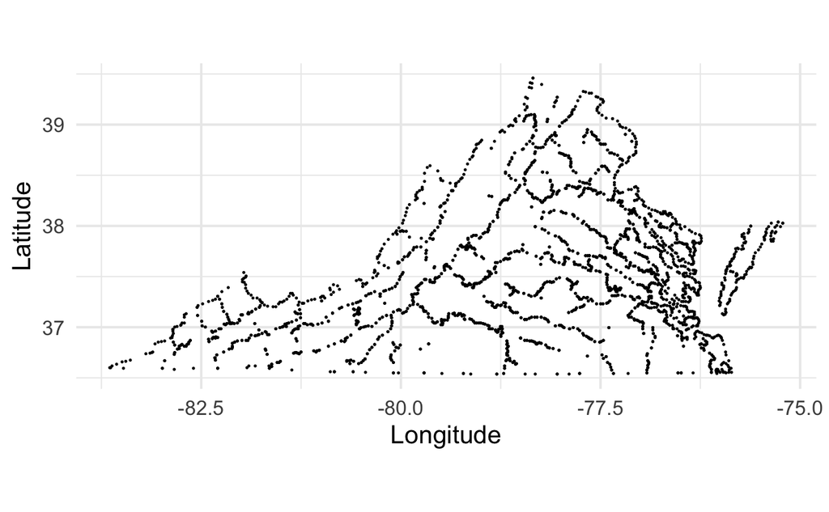

```r
ggplot( va_counties, aes( Longitude, Latitude) ) +
  geom_point( size=0.25 ) +
  coord_quickmap()
```

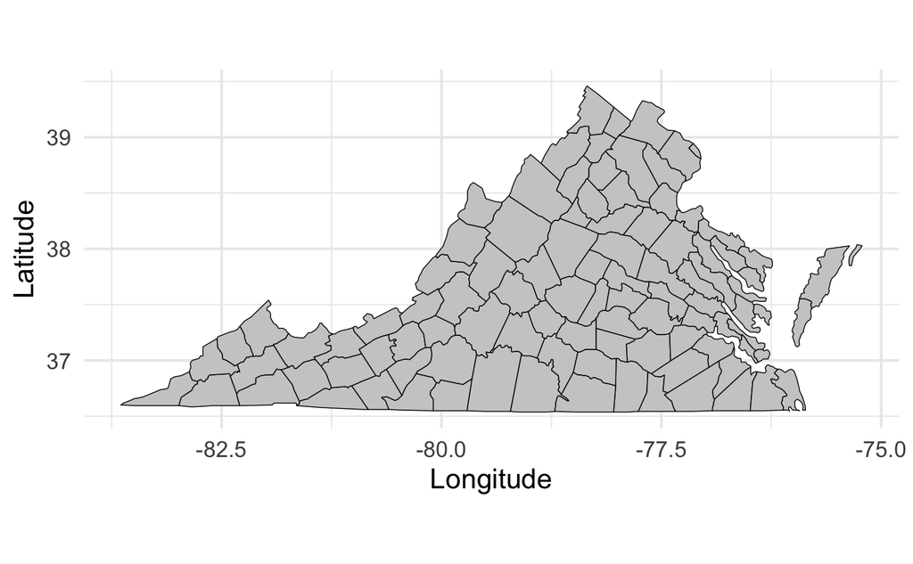

```r
ggplot( va_counties, aes( Longitude, Latitude) ) +
  geom_polygon( aes( group=group ),
                fill="grey80",
                color = "black",
                size = 0.25) +
  coord_quickmap()
```

What is hidden here is the complexity of the the points themselves. Each county is identified by a `group` in the `data.frame`

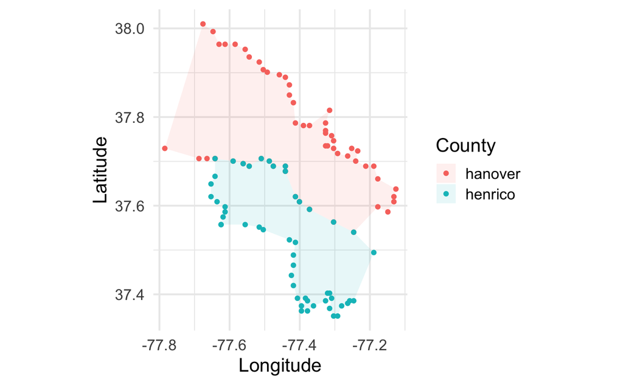

```r
va_counties %>%
  filter( County %in%  c("hanover","henrico") ) %>%
  ggplot( aes(Longitude, Latitude) ) +
  geom_polygon( aes( fill = County), alpha=0.1 ) +
  geom_point( aes( color = County) ) +
  coord_quickmap()
```

Notice that the points on the border are repeated in both `County == "hanover"` and `County == "henrico"`.

## Shapefiles

You can load in shapefile data directly into R but we have to do a little work. First, we should understand that *a shapefile* is not an actual file, it is a collection of several files. They are often zipped up into a single archive.

Here are two shape file archives that I have up on Github in the class repository.

```r
district_url <- "https://github.com/dyerlab/ENVS-Lectures/raw/master/data/Zoning_Districts-shp.zip"
roads_url <- "https://github.com/dyerlab/ENVS-Lectures/raw/master/data/Centerlines-shp.zip"
```

We can use `R` to download and unzip the file *in the current data directory* (n.b., you can do it using a browser as well).

To use `R` you need to first download them (I’ve set `eval=FALSE` to the chuck so it is not redownloaded each time. Run it by hand using `CTRL/CMD + Return`).

```r
download.file( district_url , destfile = "./Districts.zip")
download.file( roads_url, destfile =  "./Roads.zip")
```

Next, we can unzip them in the current directory.

```r
unzip( "./Districts.zip")
```

Now, go look at your directory and you will see a nice set of files named `Zoning_Districts.*`. The `*.shp` files are the actual *shapefiles* and the other stuff are supportive documentation (such as the projection in the .prj file).

```r
system("ls -al Zoning*")
```

```
-rw-r--r--  1 rodney  staff       5 Oct 27 11:35 Zoning_Districts.cpg
-rw-r--r--  1 rodney  staff  228722 Oct 27 11:35 Zoning_Districts.dbf
-rw-r--r--  1 rodney  staff     543 Oct 27 11:35 Zoning_Districts.prj
-rw-r--r--  1 rodney  staff  889268 Oct 27 11:35 Zoning_Districts.shp
-rw-r--r--  1 rodney  staff    5172 Oct 27 11:35 Zoning_Districts.shx
```

To load it in, we read the shapefile from the local directory.

```r
districts <- st_read( "Zoning_Districts.shp" )
class( districts )
```

```
[1] "sf"         "data.frame"
```

This has a lot of columns of information.

```r
names( districts )
```

```
 [1] "OBJECTID"   "Name"       "Ordinance"  "OrdinanceP" "Conditiona" "AdoptionDa" "Comment"
 [8] "CreatedBy"  "CreatedDat" "EditBy"     "EditDate"   "GlobalID"   "Shape__Are" "Shape__Len"
[15] "geometry"
```

```r
summary( districts )
```

```
    OBJECTID          Name            Ordinance          OrdinanceP         Conditiona
 Min.   :   1.0   Length:634         Length:634         Length:634         Length:634
 1st Qu.: 162.2   Class :character   Class :character   Class :character   Class :character
 Median : 324.5   Mode  :character   Mode  :character   Mode  :character   Mode  :character
 Mean   : 389.6
 3rd Qu.: 486.8
 Max.   :2677.0
   AdoptionDa           Comment           CreatedBy           CreatedDat            EditBy
 Min.   :2000-01-01   Length:634         Length:634         Min.   :2020-08-24   Length:634
 1st Qu.:2000-01-01   Class :character   Class :character   1st Qu.:2020-08-24   Class :character
 Median :2000-01-01   Mode  :character   Mode  :character   Median :2020-08-24   Mode  :character
 Mean   :2004-01-20                                         Mean   :2020-08-24
 3rd Qu.:2007-09-10                                         3rd Qu.:2020-08-24
 Max.   :2020-07-27                                         Max.   :2020-08-24
    EditDate            GlobalID           Shape__Are          Shape__Len                geometry
 Min.   :2020-08-24   Length:634         Min.   :     2823   Min.   :   213.4   MULTIPOLYGON :634
 1st Qu.:2020-08-24   Class :character   1st Qu.:    71070   1st Qu.:  1232.3   epsg:2284    :  0
 Median :2020-08-24   Mode  :character   Median :   258852   Median :  2552.3   +proj=lcc ...:  0
 Mean   :2020-08-24                      Mean   :  2749033   Mean   :  6265.9
 3rd Qu.:2020-08-24                      3rd Qu.:  1175317   3rd Qu.:  6166.8
 Max.   :2020-08-24                      Max.   :171812574   Max.   :111874.1
```

More importantly, we can look at the raw data and see the other meta data.

```r
head(districts, n=2)
```

```
Simple feature collection with 2 features and 14 fields
geometry type:  MULTIPOLYGON
dimension:      XY
bbox:           xmin: 11773600 ymin: 3730159 xmax: 11789510 ymax: 3731016
projected CRS:  NAD83 / Virginia South (ftUS)
  OBJECTID Name Ordinance OrdinanceP Conditiona AdoptionDa Comment          CreatedBy CreatedDat
1        1 RO-2      <NA>       <NA>         No 2000-01-01    <NA> richard.morton_cor 2020-08-24
2        2  B-2      <NA>       <NA>         No 2000-01-01    <NA> richard.morton_cor 2020-08-24
              EditBy   EditDate                             GlobalID Shape__Are Shape__Len
1 richard.morton_cor 2020-08-24 334799f0-fe38-46bf-97c2-260f5a036559   60150.29   983.6815
2 richard.morton_cor 2020-08-24 558df9cd-4f9c-4248-a689-bc2d9c79d060   56987.01   971.8832
                        geometry
1 MULTIPOLYGON (((11773598 37...
2 MULTIPOLYGON (((11789222 37...
```

The whole thing looks like this (I’ll use the area of each polygon as the fill color).

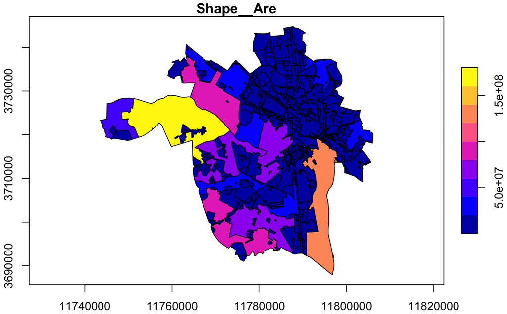

```r
plot( districts["Shape__Are"], axes=TRUE )
```

```r
districts %>%
  select( OBJECTID,
          Name,
          GlobalID,
          Area = Shape__Are,
          geometry) -> districts
head( districts )
```

```
Simple feature collection with 6 features and 4 fields
geometry type:  MULTIPOLYGON
dimension:      XY
bbox:           xmin: 11772310 ymin: 3727332 xmax: 11794670 ymax: 3731016
projected CRS:  NAD83 / Virginia South (ftUS)
  OBJECTID Name                             GlobalID      Area                       geometry
1        1 RO-2 334799f0-fe38-46bf-97c2-260f5a036559  60150.29 MULTIPOLYGON (((11773598 37...
2        2  B-2 558df9cd-4f9c-4248-a689-bc2d9c79d060  56987.01 MULTIPOLYGON (((11789222 37...
3        3  R-6 8d731cd3-7cfb-41d4-9545-44f1055515b3  93826.03 MULTIPOLYGON (((11774598 37...
4        4  B-1 f4fb1283-03ff-41e7-b5ed-3cf6e80c2e9b  17526.31 MULTIPOLYGON (((11794468 37...
5        5  B-1 f1305477-4e71-463c-a202-332971d8c5e1  33261.30 MULTIPOLYGON (((11781126 37...
6        6 RO-1 65e43734-9728-4241-921d-c657137dae0a 132773.19 MULTIPOLYGON (((11772306 37...
```

And we can plot it normally using `plot()` for `sf` objects. Each row is a `MULTIPOLYGON` object.

```r
districts %>%
  filter( OBJECTID == 368 ) %>%
  st_buffer(dist = 1500) %>%
  st_bbox() -> fan_bbox


districts %>%
  st_crop( fan_bbox ) -> theFan
```

```
attribute variables are assumed to be spatially constant throughout all geometries
```

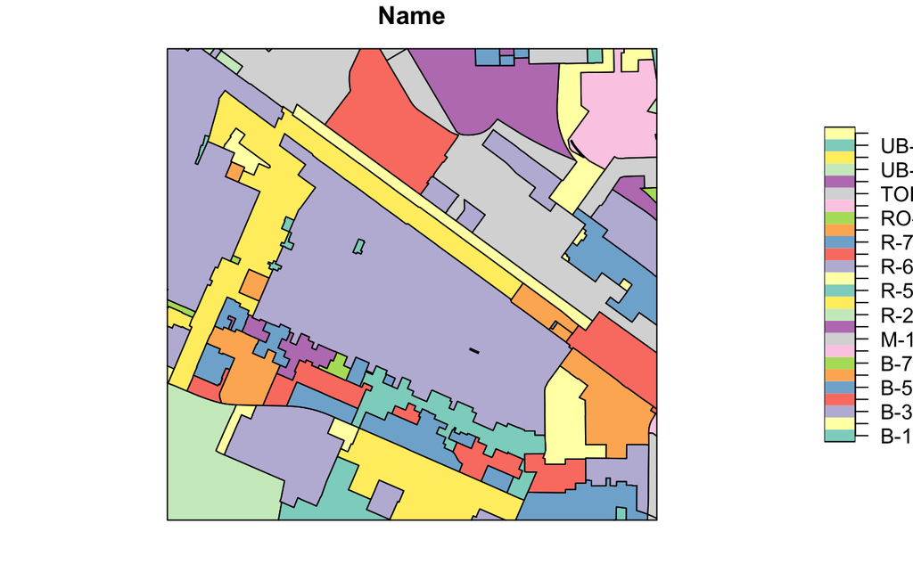

```r
plot( theFan["Name"] )
```

```r
NA
NA
```

Or as a `ggplot()` object (notice how it converts to lat/lon when plotting),

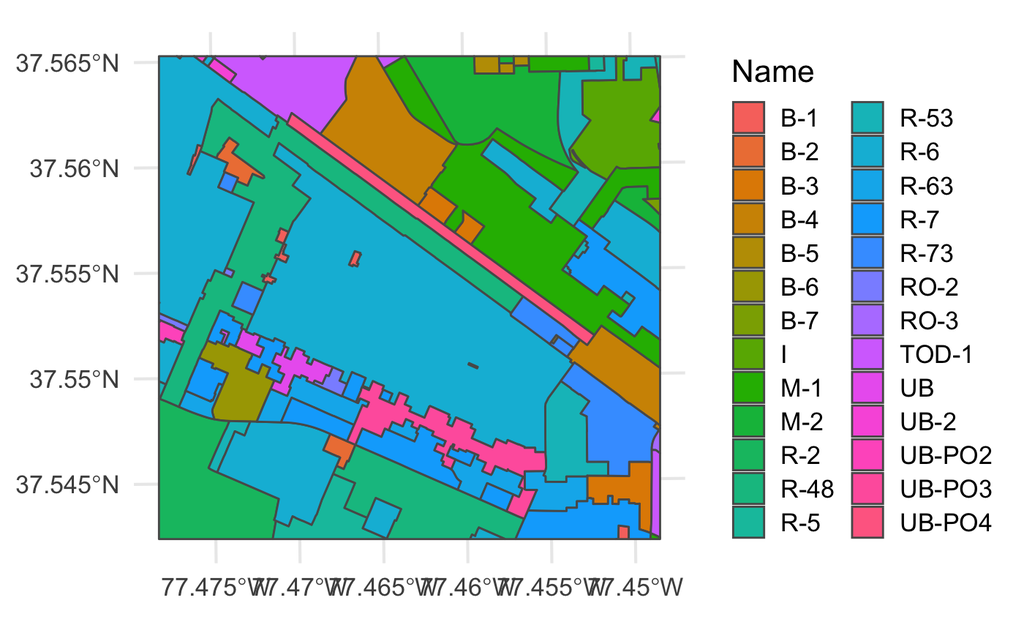

```r
ggplot( theFan ) +
  geom_sf( aes( fill=Name ) ) +
  coord_sf()
```

Let’s go grab a key to those zoning types. I’ve uploaded a csv file with a translation. Here I `left_join()` with that new file that is read in dynamically[^2].

```r
zone_url <- "https://raw.githubusercontent.com/dyerlab/ENVS-Lectures/master/data/DistrictCodes.csv"

theFan %>%
  left_join( read_csv( zone_url ),
             by="Name") %>%
  mutate( Category = factor( Category) ) %>%
  select( OBJECTID,
          Name,
          Category,
          everything() )  -> theFan
```

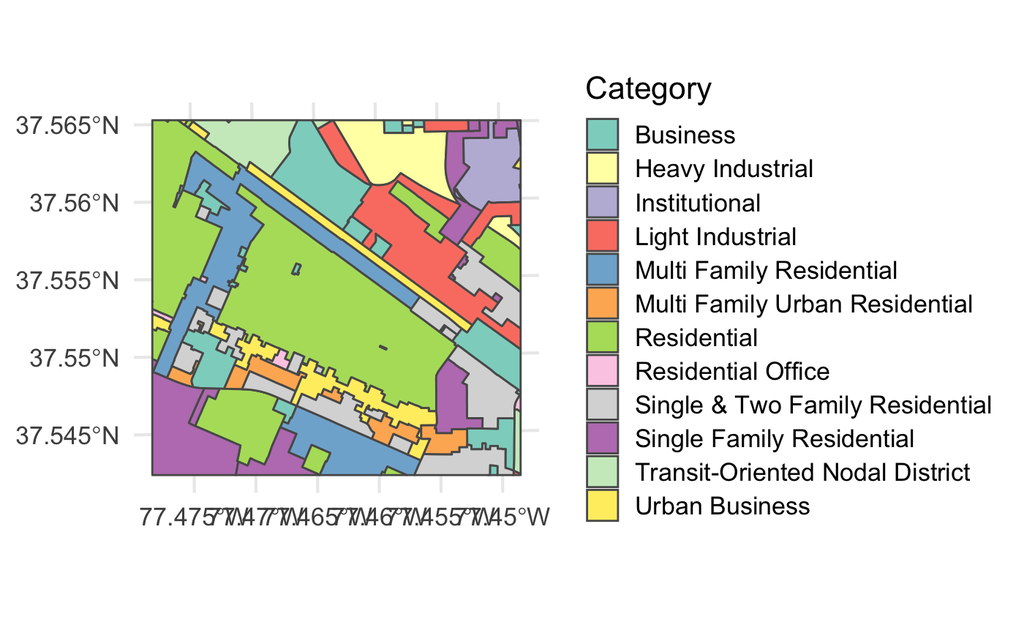

```r
ggplot( theFan ) +
  geom_sf( aes( fill=Category)) +
  scale_fill_brewer( type="qual",
                     palette = "Set3")
```

## Operations

```r
unzip( "./Roads.zip",)
st_read("Centerlines-shp/tran_Carriageway.shp") -> roads
head( roads, n=3)
```

```
Simple feature collection with 3 features and 25 fields
geometry type:  LINESTRING
dimension:      XY
bbox:           xmin: 11775970 ymin: 3733301 xmax: 11786050 ymax: 3740059
projected CRS:  NAD83 / Virginia South (ftUS)
    FID Carriagewa AssetID StreetType Functional FIPS LeftFromAd LeftToAddr RightFromA RightToAdd
1 28977     100001       2  Secondary      Local  760       <NA>       <NA>       <NA>       <NA>
2 28978     100002       3  Secondary      Local  760       1350       1398       1351       1399
3 28979      11568      89  Secondary      Local  760       1398       1300       1399       1301
  PrefixDire ProperName SuffixType SuffixDire    FullName   RouteName OneWay PostedSpee CADRouteSp
1       <NA>      Sauer        Ave       <NA>   Sauer Ave   Sauer Ave   <NA>         25         25
2       <NA>      Sauer        Ave       <NA>   Sauer Ave   Sauer Ave   <NA>         25         25
3       <NA>    Amherst        Ave       <NA> Amherst Ave Amherst Ave   <NA>         25         25
      CreatedBy CreatedDat        EditBy   EditDate                               GlobalID SHAPE_Leng
1 richmondvagis 2020-05-20 richmondvagis 2020-05-20 {936CDFAD-9A7E-4CE5-A0BD-215DF5CD916D}   56.04379
2 richmondvagis 2020-05-20 richmondvagis 2020-05-20 {0E1D804B-81B1-4A83-9945-A898D1AB9929}  114.64042
3 richmondvagis 2020-05-20 richmondvagis 2020-05-20 {143E5038-4065-47F9-BF86-C709623E7752}  648.63684
                        geometry
1 LINESTRING (11775968 373330...
2 LINESTRING (11775997 373334...
3 LINESTRING (11785407 374003...
```

Let’s clean it up a bit.

```r
roads %>%
  select( -CreatedBy, -CreatedDat, -EditBy, -EditDate) -> roads
head( roads )
```

```
Simple feature collection with 6 features and 21 fields
geometry type:  LINESTRING
dimension:      XY
bbox:           xmin: 11775970 ymin: 3733301 xmax: 11789860 ymax: 3740429
projected CRS:  NAD83 / Virginia South (ftUS)
    FID Carriagewa AssetID StreetType Functional FIPS LeftFromAd LeftToAddr RightFromA RightToAdd
1 28977     100001       2  Secondary      Local  760       <NA>       <NA>       <NA>       <NA>
2 28978     100002       3  Secondary      Local  760       1350       1398       1351       1399
3 28979      11568      89  Secondary      Local  760       1398       1300       1399       1301
4 28980      11691      91  Secondary      Local  760       4200       4210       4201       4207
5 28981      11731      92  Secondary      Local  760       4000       4022       4001       4011
6 28982      11744      93  Secondary      Local  760       4100       4112       4101       4111
  PrefixDire ProperName SuffixType SuffixDire    FullName   RouteName OneWay PostedSpee CADRouteSp
1       <NA>      Sauer        Ave       <NA>   Sauer Ave   Sauer Ave   <NA>         25         25
2       <NA>      Sauer        Ave       <NA>   Sauer Ave   Sauer Ave   <NA>         25         25
3       <NA>    Amherst        Ave       <NA> Amherst Ave Amherst Ave   <NA>         25         25
4       <NA>     Corbin         St       <NA>   Corbin St   Corbin St   <NA>         25         25
5       <NA>      Piney       Road       <NA>  Piney Road  Piney Road   <NA>         25         25
6       <NA>     Corbin         St       <NA>   Corbin St   Corbin St   <NA>         25         25
                                GlobalID SHAPE_Leng                       geometry
1 {936CDFAD-9A7E-4CE5-A0BD-215DF5CD916D}   56.04379 LINESTRING (11775968 373330...
2 {0E1D804B-81B1-4A83-9945-A898D1AB9929}  114.64042 LINESTRING (11775997 373334...
3 {143E5038-4065-47F9-BF86-C709623E7752}  648.63684 LINESTRING (11785407 374003...
4 {B6F87A01-C957-4FBC-91EB-62E20BFAA570}  295.54859 LINESTRING (11789753 374015...
5 {9666C05E-556C-454E-AA40-1D5B5835578F}  311.83570 LINESTRING (11788684 373991...
6 {0A9FC39D-C1F8-4BB3-9C09-12C5592FBAA2}  306.21940 LINESTRING (11789640 373986...
```

```r
plot( theFan$geometry, lwd=2 )
fanRoads <- st_crop( roads, st_bbox( theFan ))
```

```
attribute variables are assumed to be spatially constant throughout all geometries
```

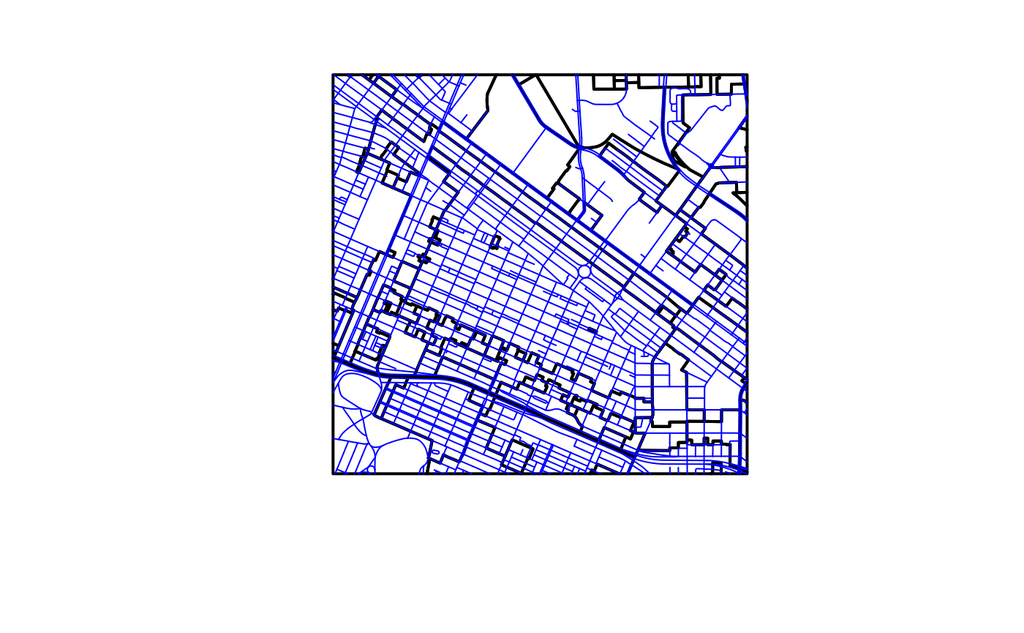

```r
plot( fanRoads$geometry, col="blue", cex=0.5, add=TRUE )
```

Let’s isolate one of the main polygons in `theFan` data set. The target one below is indicated by `OBJECTID=368`.

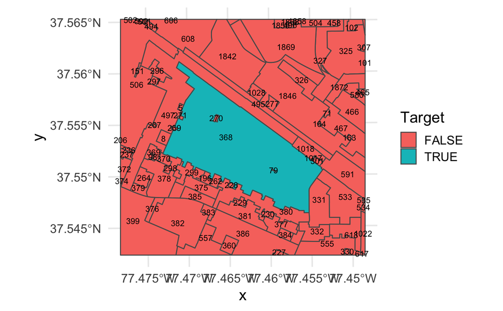

```r
theFan %>%
  mutate( Target = ifelse( OBJECTID == 368,
                           TRUE,
                           FALSE) ) -> theFan


theFan %>%
  ggplot() +
  geom_sf( aes(fill=Target) ) +
  geom_sf_text( aes(label=OBJECTID), size=3 ) +
  coord_sf()
```

## Spatial Joins

```r
names( fanRoads )
```

```
 [1] "FID"        "Carriagewa" "AssetID"    "StreetType" "Functional" "FIPS"       "LeftFromAd"
 [8] "LeftToAddr" "RightFromA" "RightToAdd" "PrefixDire" "ProperName" "SuffixType" "SuffixDire"
[15] "FullName"   "RouteName"  "OneWay"     "PostedSpee" "CADRouteSp" "GlobalID"   "SHAPE_Leng"
[22] "geometry"
```

We can use *spatial joins* to select features either directly. Here I’ll use the target polygon in `theFan`

```r
target
```

[output not shown]

```
Simple feature collection with 1 feature and 6 fields
geometry type:  POLYGON
dimension:      XY
bbox:           xmin: 11780610 ymin: 3724146 xmax: 11786260 ymax: 3729483
projected CRS:  NAD83 / Virginia South (ftUS)
   OBJECTID Name    Category                             GlobalID     Area                       geometry
39      368  R-6 Residential d9882dad-2625-44e7-a170-3f1425450679 13040977 POLYGON ((11785182 3726534,...
   Target
39   TRUE
```

```r
summary( fanRoads$OnTarget )
```

```
     V1
 Mode :logical
 FALSE:1567
 TRUE :553
```

We can get the names of these road using normal `dplyr` routines,

| Street Name |
| --- |
| Allison St |
| Birch St |
| Boyd St |
| Floyd Ave |
| Grove Ave |
| Hanover Ave |
| Kensington Ave |
| Lombardy Pl |
| Madumbie Lane |
| Monument Ave |

[output cut: 29 more lines]

And we can plot them as:

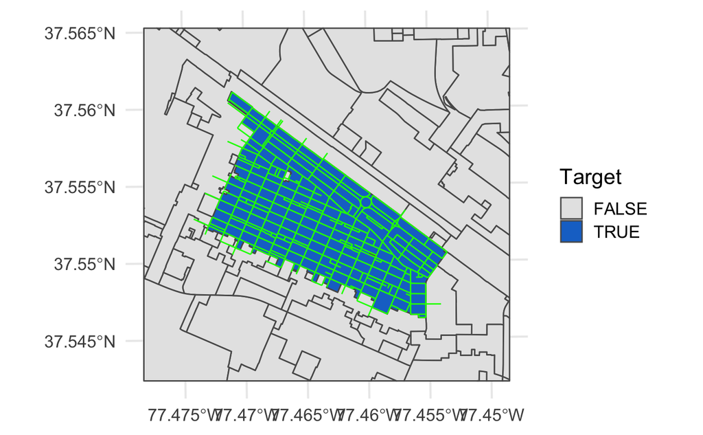

Go check out the `sf` cheatsheet for more geospatial joins and options.

[^1]: **Dyer’s First Law: Reproject then forget**.
[^2]: You should be careful when you use joins on `sf` objects. If you `sf` object is on the right side (see discussion of joins [here](https://dyerlab.github.io/ENVS-Lectures/manipulation/relational_data/slides.html#5)) then the result will not be an `sf` object and you’ll have to coerce it back into one again. It always adopts the characteristics of the left object.